# Unsupervised Learning: Trade&Ahead

**Marks: 60**

### Context

The stock market has consistently proven to be a good place to invest in and save for the future. There are a lot of compelling reasons to invest in stocks. It can help in fighting inflation, create wealth, and also provides some tax benefits. Good steady returns on investments over a long period of time can also grow a lot more than seems possible. Also, thanks to the power of compound interest, the earlier one starts investing, the larger the corpus one can have for retirement. Overall, investing in stocks can help meet life's financial aspirations.

It is important to maintain a diversified portfolio when investing in stocks in order to maximise earnings under any market condition. Having a diversified portfolio tends to yield higher returns and face lower risk by tempering potential losses when the market is down. It is often easy to get lost in a sea of financial metrics to analyze while determining the worth of a stock, and doing the same for a multitude of stocks to identify the right picks for an individual can be a tedious task. By doing a cluster analysis, one can identify stocks that exhibit similar characteristics and ones which exhibit minimum correlation. This will help investors better analyze stocks across different market segments and help protect against risks that could make the portfolio vulnerable to losses.

### Objective

Trade&Ahead is a financial consultancy firm who provide their customers with personalized investment strategies. They have hired you as a Data Scientist and provided you with data comprising stock price and some financial indicators for a few companies listed under the New York Stock Exchange. They have assigned you the tasks of analyzing the data, grouping the stocks based on the attributes provided, and sharing insights about the characteristics of each group.

### Data Dictionary

- Ticker Symbol: An abbreviation used to uniquely identify publicly traded shares of a particular stock on a particular stock market
- Company: Name of the company
- GICS Sector: The specific economic sector assigned to a company by the Global Industry Classification Standard (GICS) that best defines its business operations
- GICS Sub Industry: The specific sub-industry group assigned to a company by the Global Industry Classification Standard (GICS) that best defines its business operations
- Current Price: Current stock price in dollars
- Price Change: Percentage change in the stock price in 13 weeks
- Volatility: Standard deviation of the stock price over the past 13 weeks
- ROE: A measure of financial performance calculated by dividing net income by shareholders' equity (shareholders' equity is equal to a company's assets minus its debt)
- Cash Ratio: The ratio of a company's total reserves of cash and cash equivalents to its total current liabilities
- Net Cash Flow: The difference between a company's cash inflows and outflows (in dollars)
- Net Income: Revenues minus expenses, interest, and taxes (in dollars)
- Earnings Per Share: Company's net profit divided by the number of common shares it has outstanding (in dollars)
- Estimated Shares Outstanding: Company's stock currently held by all its shareholders
- P/E Ratio: Ratio of the company's current stock price to the earnings per share
- P/B Ratio: Ratio of the company's stock price per share by its book value per share (book value of a company is the net difference between that company's total assets and total liabilities)

## Importing necessary libraries and data

```python
# this will help in making the Python code more structured automatically (good coding practice)
#%load_ext nb_black

# Libraries to help with reading and manipulating data
import numpy as np
import pandas as pd

# Libraries to help with data visualization
import matplotlib.pyplot as plt
import seaborn as sns

# Removes the limit for the number of displayed columns
pd.set_option("display.max_columns", None)
# Sets the limit for the number of displayed rows
pd.set_option("display.max_rows", 200)

# to scale the data using z-score
from sklearn.preprocessing import StandardScaler

# to compute distances
from scipy.spatial.distance import pdist
from scipy.spatial.distance import cdist

# to perform hierarchical clustering, compute cophenetic correlation, and create dendrograms
from sklearn.cluster import AgglomerativeClustering
from sklearn.cluster import KMeans
from scipy.cluster.hierarchy import dendrogram, linkage, cophenet

from sklearn.metrics import silhouette_score

from yellowbrick.cluster import KElbowVisualizer, SilhouetteVisualizer
# to perform PCA
from sklearn.decomposition import PCA
```

```python
from google.colab import drive
drive.mount('/content/drive')
```

```python
df = pd.read_csv("/content/drive/MyDrive/stock_data.csv")
```

## Data Overview

- Observations
- Sanity checks

```python
df.head()
```

|  | Ticker Symbol | Security | GICS Sector | GICS Sub Industry | Current Price | Price Change | Volatility | ROE | Cash Ratio | Net Cash Flow | Net Income | Earnings Per Share | Estimated Shares Outstanding | P/E Ratio | P/B Ratio |
| --- | --- | --- | --- | --- | --- | --- | --- | --- | --- | --- | --- | --- | --- | --- | --- |
| 0 | AAL | American Airlines Group | Industrials | Airlines | 42.349998 | 9.999995 | 1.687151 | 135 | 51 | -604000000 | 7610000000 | 11.39 | 6.681299e+08 | 3.718174 | -8.784219 |
| 1 | ABBV | AbbVie | Health Care | Pharmaceuticals | 59.240002 | 8.339433 | 2.197887 | 130 | 77 | 51000000 | 5144000000 | 3.15 | 1.633016e+09 | 18.806350 | -8.750068 |
| 2 | ABT | Abbott Laboratories | Health Care | Health Care Equipment | 44.910000 | 11.301121 | 1.273646 | 21 | 67 | 938000000 | 4423000000 | 2.94 | 1.504422e+09 | 15.275510 | -0.394171 |
| 3 | ADBE | Adobe Systems Inc | Information Technology | Application Software | 93.940002 | 13.977195 | 1.357679 | 9 | 180 | -240840000 | 629551000 | 1.26 | 4.996437e+08 | 74.555557 | 4.199651 |
| 4 | ADI | Analog Devices, Inc. | Information Technology | Semiconductors | 55.320000 | -1.827858 | 1.701169 | 14 | 272 | 315120000 | 696878000 | 0.31 | 2.247994e+09 | 178.451613 | 1.059810 |

## Exploratory Data Analysis (EDA)

- EDA is an important part of any project involving data.
- It is important to investigate and understand the data better before building a model with it.
- A few questions have been mentioned below which will help you approach the analysis in the right manner and generate insights from the data.
- A thorough analysis of the data, in addition to the questions mentioned below, should be done.

**Questions**:

1. What does the distribution of stock prices look like?
2. The stocks of which economic sector have seen the maximum price increase on average?
3. How are the different variables correlated with each other?
4. Cash ratio provides a measure of a company's ability to cover its short-term obligations using only cash and cash equivalents. How does the average cash ratio vary across economic sectors?
5. P/E ratios can help determine the relative value of a company's shares as they signify the amount of money an investor is willing to invest in a single share of a company per dollar of its earnings. How does the P/E ratio vary, on average, across economic sectors?

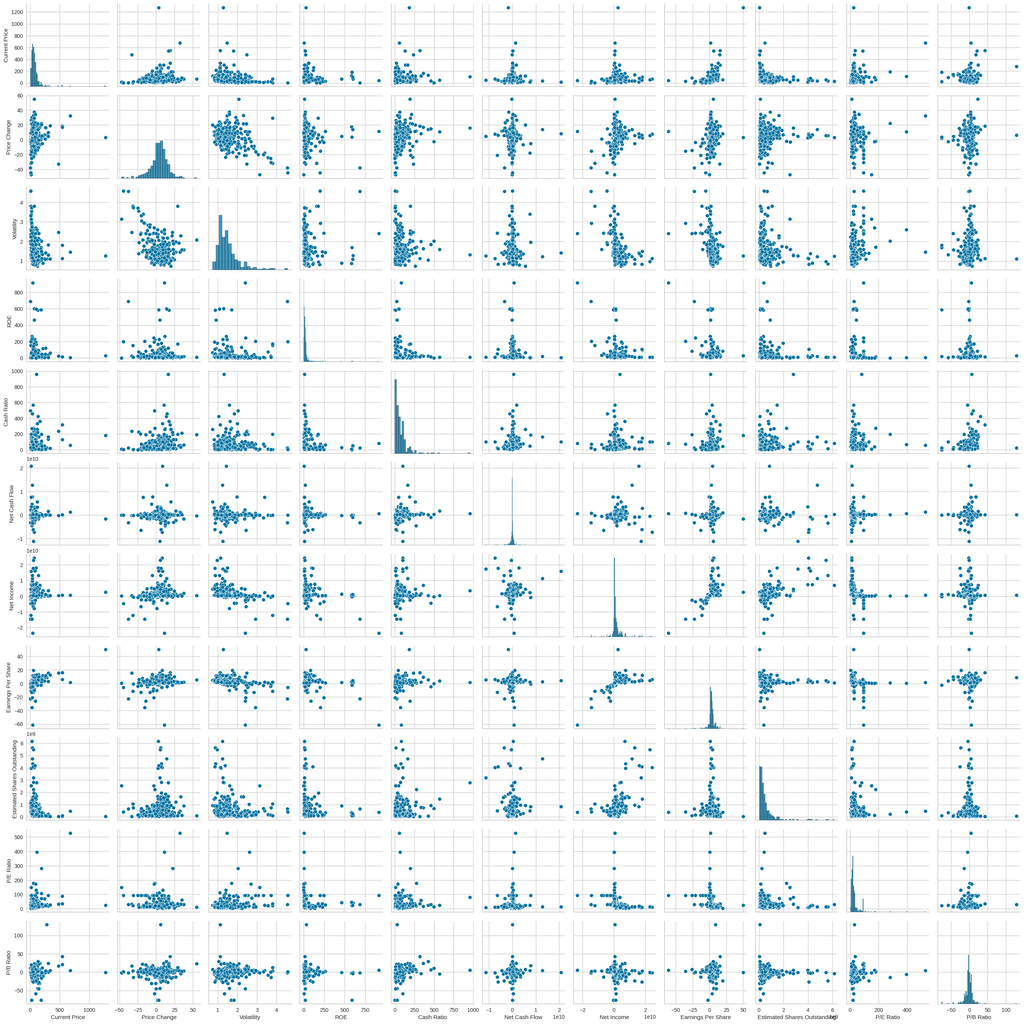

```python
sns.pairplot(data = df)
```

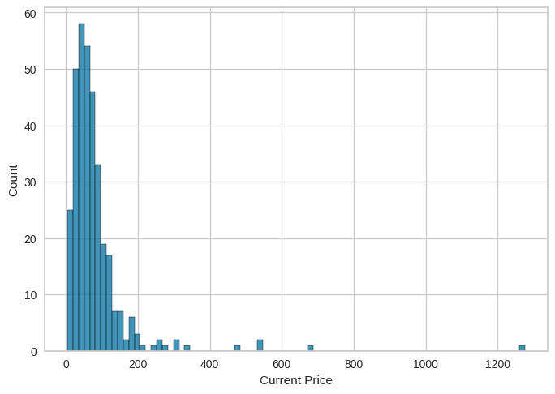

```python
sns.histplot(data = df, x = "Current Price")
```

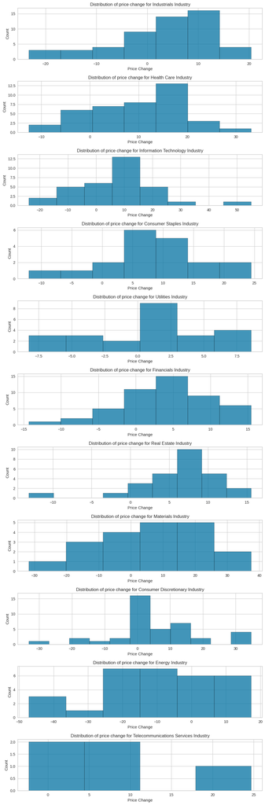

```python
fig, axs = plt.subplots(nrows = len(df["GICS Sector"].unique()), ncols = 1, figsize = (10,30))
for i, industry in enumerate(df["GICS Sector"].unique()):
  #print(i)
  sns.histplot(data = df.loc[df["GICS Sector"] == industry], x = "Price Change", ax = axs[i])
  axs[i].set_title("Distribution of price change for " + industry + " Industry")
  #plt.title("Histogram for price change in " + i)

plt.tight_layout()
plt.show()
```

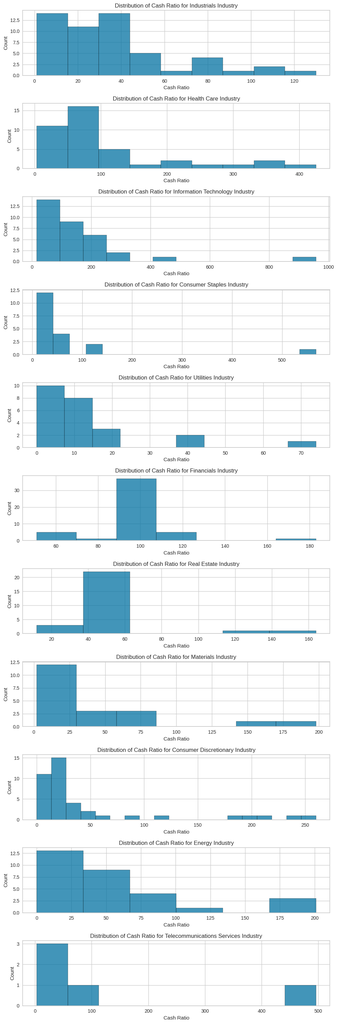

```python
fig, axs = plt.subplots(nrows = len(df["GICS Sector"].unique()), ncols = 1, figsize = (10,30))
for i, industry in enumerate(df["GICS Sector"].unique()):
  #print(i)
  sns.histplot(data = df.loc[df["GICS Sector"] == industry], x = "Cash Ratio", ax = axs[i])
  axs[i].set_title("Distribution of Cash Ratio for " + industry + " Industry")
  #plt.title("Histogram for price change in " + i)

plt.tight_layout()
plt.show()
```

This is the same categorization of distributions, except for cash ratio. Cash ratio is a measure of a companies ability to pay liabilities with cash reserves. The highest cash ratio based on histograms is the IT industry

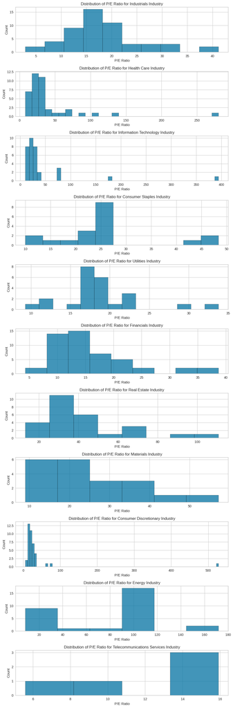

```python
fig, axs = plt.subplots(nrows = len(df["GICS Sector"].unique()), ncols = 1, figsize = (10,30))
for i, industry in enumerate(df["GICS Sector"].unique()):
  #print(i)
  sns.histplot(data = df.loc[df["GICS Sector"] == industry], x = "P/E Ratio", ax = axs[i])
  axs[i].set_title("Distribution of P/E Ratio for " + industry + " Industry")
  #plt.title("Histogram for price change in " + i)

plt.tight_layout()
plt.show()
```

Now, the distributions for P/E Ratio across industries. P/E ratio is the measure of a stocks price over earnings per share. The industry with the highest P/E ratio is the energy industry.

## Data Preprocessing

- Duplicate value check
- Missing value treatment
- Outlier check
- Feature engineering (if needed)
- Any other preprocessing steps (if needed)

```python
num_col = df.select_dtypes(include=np.number).columns.tolist()
```

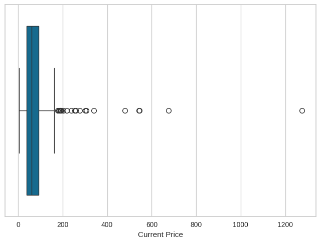

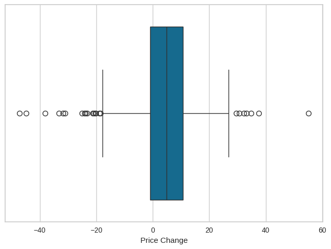

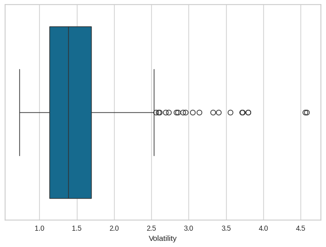

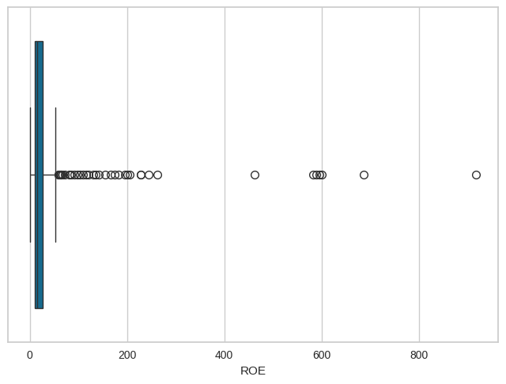

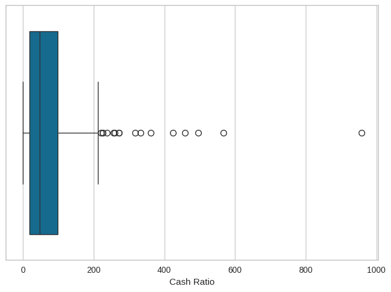

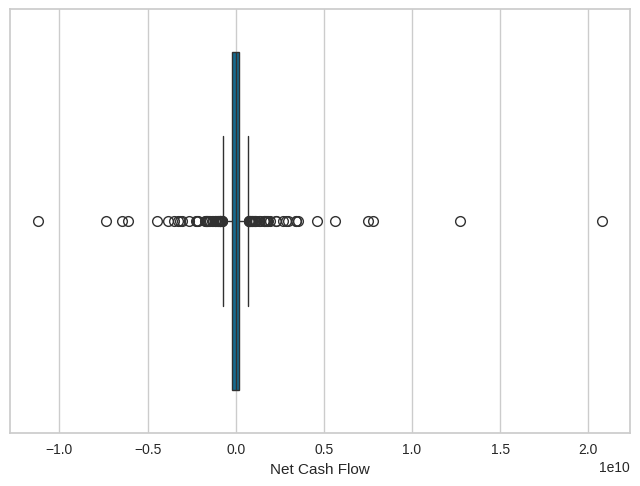

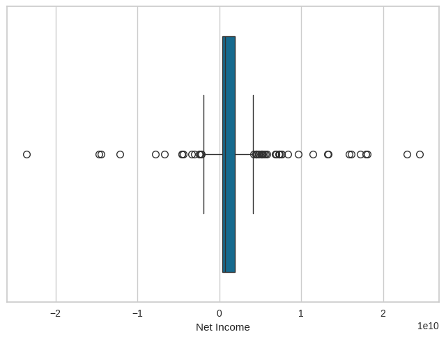

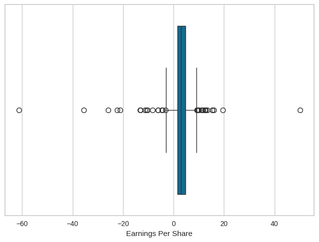

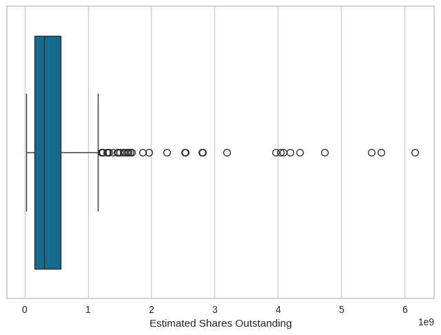

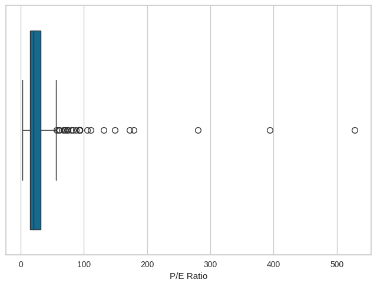

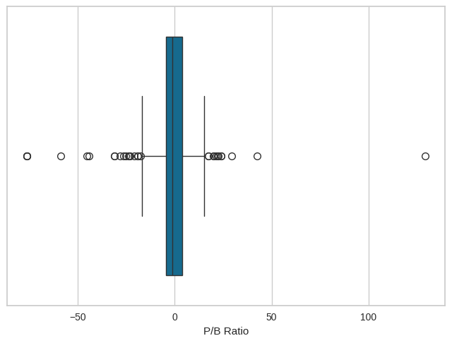

```python
df_numeric_cols = df.select_dtypes(include = np.number)
for i in df_numeric_cols:
  sns.boxplot(data = df_numeric_cols, x = i)
  plt.show()
```

Checking boxplots for outliers

```python
for i in df_numeric_cols:
  Q1 = df[i].quantile(0.25)
  Q3 = df[i].quantile(0.75)
  IQR = Q3 - Q1
  low_end = Q1 - (1.5 * IQR)
  high_end = Q3 + (1.5 * IQR)

  df[i] = np.clip(df[i], low_end, high_end)
```

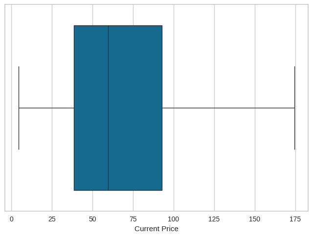

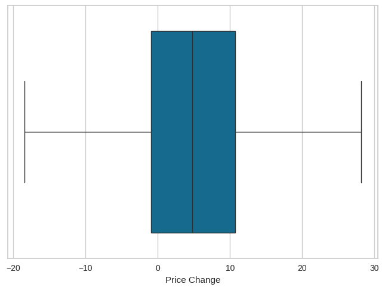

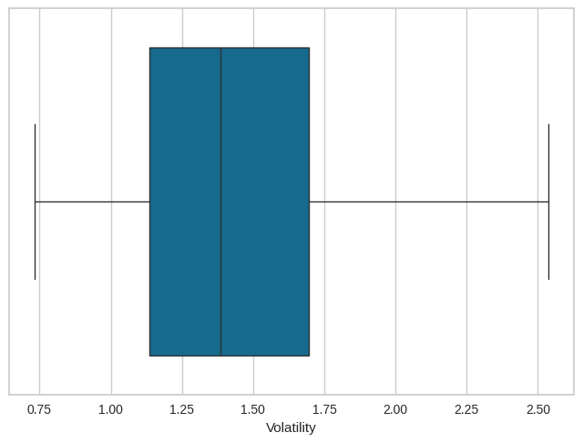

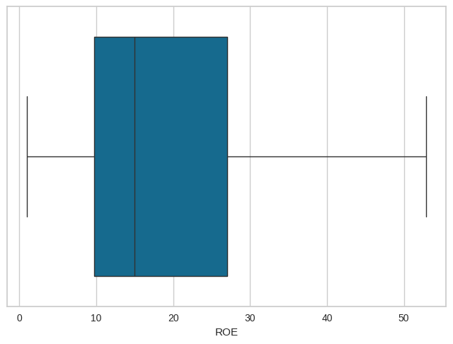

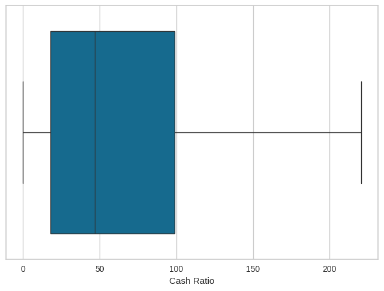

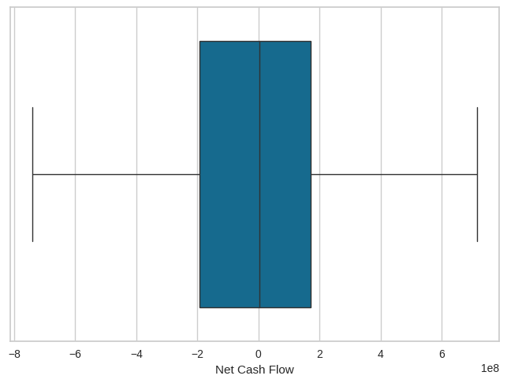

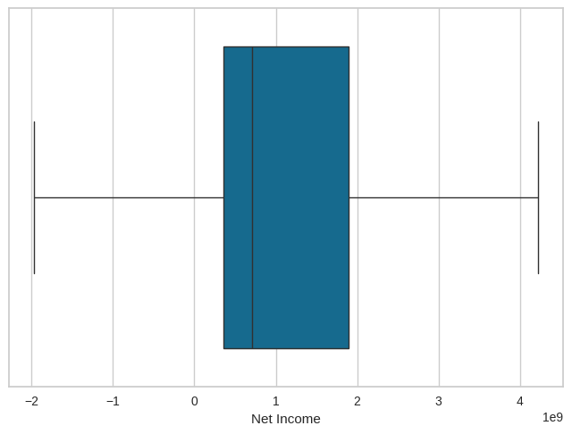

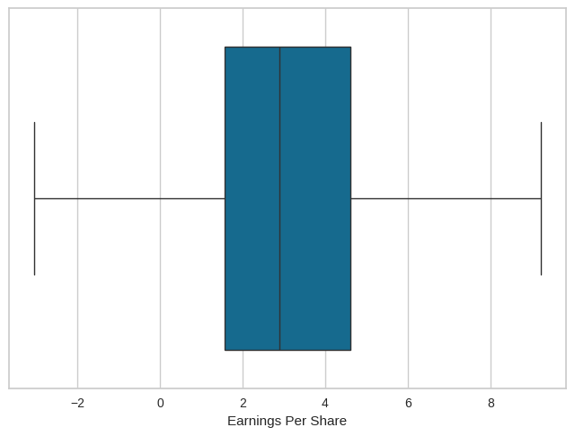

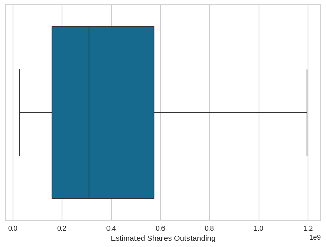

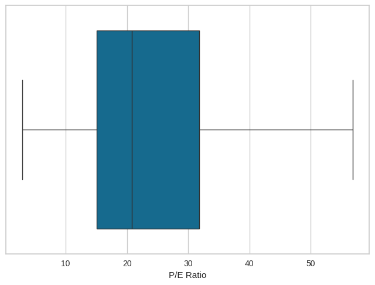

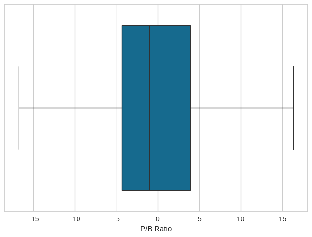

```python
df_numeric_cols = df.select_dtypes(include = np.number)
for i in df_numeric_cols:
  sns.boxplot(data = df_numeric_cols, x = i)
  plt.show()
```

Treating outliers with quantile values as done previously.

## EDA

- It is a good idea to explore the data once again after manipulating it.

## K-means Clustering

```python
scaler = StandardScaler()
num_subset = df_numeric_cols.copy()
scaled_subset = scaler.fit_transform(num_subset)
```

```python
subset_scaled_df = pd.DataFrame(scaled_subset, columns = num_subset.columns)
```

```
Number of Clusters: 1 	Average Distortion: 3.1482665386211908
Number of Clusters: 2 	Average Distortion: 2.9512720112654662
Number of Clusters: 3 	Average Distortion: 2.759761533270845
Number of Clusters: 4 	Average Distortion: 2.6314842401177394
Number of Clusters: 5 	Average Distortion: 2.535998103618197
Number of Clusters: 6 	Average Distortion: 2.4548292484717584
Number of Clusters: 7 	Average Distortion: 2.3888889238999664
Number of Clusters: 8 	Average Distortion: 2.3442283422132117
```

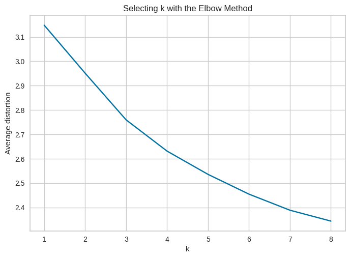

```python
clusters = range(1, 9)
meanDistortions = []

for k in clusters:
    model = KMeans(n_clusters=k)
    prediction = model.fit_predict(subset_scaled_df)
    distortion = (
        sum(
            np.min(cdist(subset_scaled_df, model.cluster_centers_, "euclidean"), axis=1)
        )
        / subset_scaled_df.shape[0]
    )

    meanDistortions.append(distortion)

    print("Number of Clusters:", k, "\tAverage Distortion:", distortion)

plt.plot(clusters, meanDistortions, "bx-")
plt.xlabel("k")
plt.ylabel("Average distortion")
plt.title("Selecting k with the Elbow Method")
plt.show()
```

Doing K Means clustering for different values of K and plotting the average distortion for the model on each K.

```
For n_clusters = 2, the silhouette score is 0.1334867211279908)
For n_clusters = 3, the silhouette score is 0.1782653193107335)
For n_clusters = 4, the silhouette score is 0.16897362521781661)
For n_clusters = 5, the silhouette score is 0.15074536339981756)
```

```
For n_clusters = 6, the silhouette score is 0.15018768424679968)
For n_clusters = 7, the silhouette score is 0.15049375605859258)
```

```
For n_clusters = 8, the silhouette score is 0.12755739067479727)
For n_clusters = 9, the silhouette score is 0.12508213010881677)
```

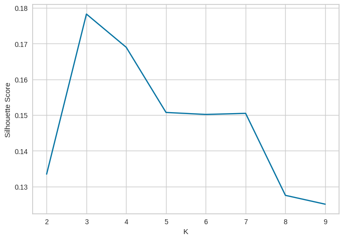

```python
sil_score = []
cluster_list = list(range(2, 10))
for n_clusters in cluster_list:
    clusterer = KMeans(n_clusters=n_clusters)
    preds = clusterer.fit_predict((subset_scaled_df))
    # centers = clusterer.cluster_centers_
    score = silhouette_score(subset_scaled_df, preds)
    sil_score.append(score)
    print("For n_clusters = {}, the silhouette score is {})".format(n_clusters, score))

plt.plot(cluster_list, sil_score)
plt.xlabel("K")
plt.ylabel("Silhouette Score")
plt.show()
```

Measuring silhouette scores for different values of K.

Based on both the distortion graph as well as the silhouette score graph, It seems that the optimal amount of clusters for building a k-means model is 3.

```python
KMModel = KMeans(n_clusters = 3, random_state = 1)
KMModel.fit(subset_scaled_df)
```

```
KMeans(n_clusters=3, random_state=1)
```

```python
subset_scaled_df["KM_Clusters"] = KMModel.labels_
df["KM_Clusters"] = KMModel.labels_
```

```python
cluster_profile = subset_scaled_df.groupby("KM_Clusters").mean()
```

```python
cluster_profile["count_in_each_segments"] = (
    subset_scaled_df.groupby("KM_Clusters")["Current Price"].count().values
)
```

```python
cluster_profile.style.highlight_max(color="lightgreen", axis=0)
```

| KM_Clusters | Current Price | Price Change | Volatility | ROE | Cash Ratio | Net Cash Flow | Net Income | Earnings Per Share | Estimated Shares Outstanding | P/E Ratio | P/B Ratio | count_in_each_segments |
| --- | --- | --- | --- | --- | --- | --- | --- | --- | --- | --- | --- | --- |
| 0 | 0.040151 | 0.333444 | -0.365159 | 0.235266 | 0.167762 | 0.112685 | 1.429179 | 0.546909 | 1.283325 | -0.485551 | -0.026561 | 81 |
| 1 | 0.131179 | 0.067881 | -0.207158 | -0.125320 | -0.115687 | -0.033783 | -0.299953 | 0.077692 | -0.527143 | -0.080824 | -0.088656 | 216 |
| 2 | -0.734582 | -0.969099 | 1.728463 | 0.186337 | 0.265107 | -0.042566 | -1.185432 | -1.420489 | 0.230549 | 1.320644 | 0.495377 | 43 |

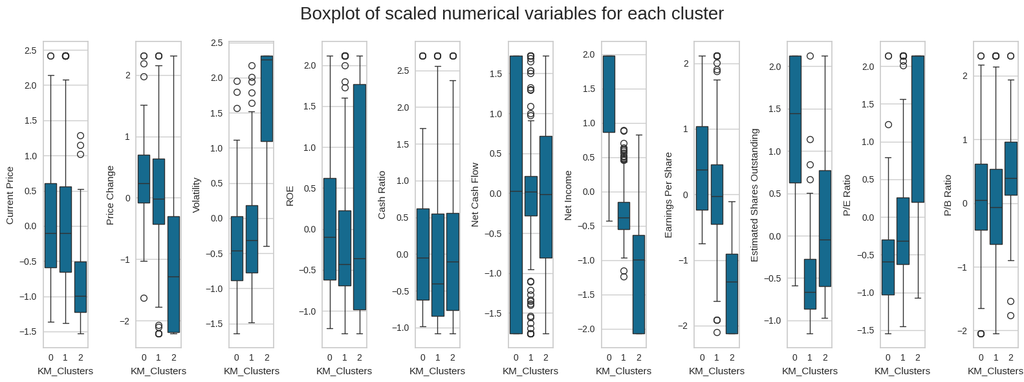

```python
fig, axes = plt.subplots(1, 11, figsize=(16, 6))
fig.suptitle("Boxplot of scaled numerical variables for each cluster", fontsize=20)
counter = 0
for i in range(11):
    sns.boxplot(
        ax=axes[i],
        y=subset_scaled_df[num_col[counter]],
        x=subset_scaled_df["KM_Clusters"],
    )
    counter = counter + 1

fig.tight_layout()
```

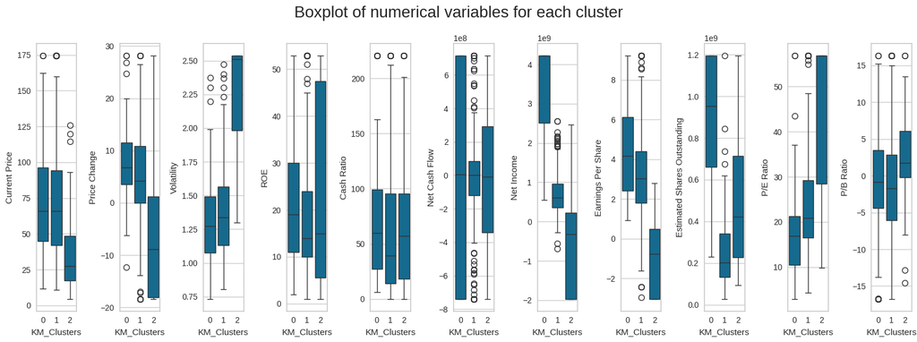

```python
fig, axes = plt.subplots(1, 11, figsize=(16, 6))
fig.suptitle("Boxplot of numerical variables for each cluster", fontsize=20)
counter = 0
for i in range(11):
    sns.boxplot(
        ax=axes[i],
        y=df[num_col[counter]],
        x=df["KM_Clusters"],
    )
    counter = counter + 1

fig.tight_layout()
```

Boxplots for each numeric variable categorized by the clusters each company was put in.

Cluster 1:

Cluster 1 companies typically have the median average values out of the three clusters

Cluster 2:

```python
for cl in df["KM_Clusters"].unique():
    print("In cluster {}, the following companies are present:".format(cl))
    print(df[subset_scaled_df["KM_Clusters"] == cl]["Security"].unique())
    print()
```

```
In cluster 0, the following companies are present:
['American Airlines Group' 'AbbVie' 'Abbott Laboratories' 'AFLAC Inc'
 'American International Group, Inc.' 'Applied Materials Inc' 'Amgen Inc'
 'Broadcom' 'American Express Co' 'Boeing Company' 'Bank of America Corp'
 'BB&T Corporation' 'BIOGEN IDEC Inc.' 'The Bank of New York Mellon Corp.'
 'Bristol-Myers Squibb' 'Citigroup Inc.' 'Caterpillar Inc.'
 'Chubb Limited' 'Carnival Corp.' 'Colgate-Palmolive'
 'Capital One Financial' 'CSX Corp.' 'CVS Health' 'Chevron Corp.'
 'Delta Air Lines' 'Du Pont (E.I.)' 'Discover Financial Services'
 'Danaher Corp.' 'The Walt Disney Company' 'Duke Energy' 'eBay Inc.'
 'Ford Motor' 'Facebook' 'General Dynamics' 'Gilead Sciences'
 'Corning Inc.' 'General Motors' "Honeywell Int'l Inc." 'HP Inc.'
 'International Business Machines' 'Intel Corp.' 'JPMorgan Chase & Co.'
 'Coca Cola Company' 'Lilly (Eli) & Co.' 'Lockheed Martin Corp.'
 'Southwest Airlines' 'Level 3 Communications' 'LyondellBasell'
 'Mastercard Inc.' "McDonald's Corp." 'Mondelez International'
 'MetLife Inc.' '3M Company' 'Monster Beverage' 'Altria Group Inc'
 'Marathon Petroleum' 'Merck & Co.' 'Mylan N.V.' 'NextEra Energy'
 'PepsiCo Inc.' 'Pfizer Inc.' 'Philip Morris International'
 'PNC Financial Services' 'Prudential Financial' 'Phillips 66' 'PayPal'
 'Charles Schwab Corporation' 'Southern Co.' 'Synchrony Financial'
 'AT&T Inc' 'The Travelers Companies Inc.' 'Texas Instruments'
 'United Continental Holdings' 'United Health Group Inc.' 'Union Pacific'
 'United Parcel Service' 'United Technologies' 'Valero Energy'
 'Verizon Communications' 'Wells Fargo' 'Exxon Mobil Corp.']

In cluster 1, the following companies are present:
['Adobe Systems Inc' 'Archer-Daniels-Midland Co' 'Alliance Data Systems'
 'Ameren Corp' 'American Electric Power' 'Apartment Investment & Mgmt'
 'Assurant Inc' 'Arthur J. Gallagher & Co.' 'Akamai Technologies Inc'
 'Albemarle Corp' 'Alaska Air Group Inc' 'Allstate Corp' 'Allegion'
 'Alexion Pharmaceuticals' 'AMETEK Inc' 'Affiliated Managers Group Inc'
 'Ameriprise Financial' 'American Tower Corp A' 'Amazon.com Inc'
 'AutoNation Inc' 'Anthem Inc.' 'Aon plc' 'Amphenol Corp'
 'Activision Blizzard' 'AvalonBay Communities, Inc.'
 'American Water Works Company Inc' 'Baxter International Inc.'
 'Bard (C.R.) Inc.' 'Ball Corp' 'Boston Scientific' 'BorgWarner'
 'Boston Properties' 'CBRE Group' 'Crown Castle International Corp.'
 'CF Industries Holdings Inc' 'Citizens Financial Group' 'Church & Dwight'
 'C. H. Robinson Worldwide' 'Charter Communications' 'CIGNA Corp.'
```

[output cut: 55 more lines]

```

In cluster 2, the following companies are present:
['Analog Devices, Inc.' 'Apache Corporation' 'Anadarko Petroleum Corp'
 'Arconic Inc' 'Baker Hughes Inc' 'Celgene Corp.' 'Chesapeake Energy'
 'Cabot Oil & Gas' 'Concho Resources' 'Devon Energy Corp.' 'EOG Resources'
 'EQT Corporation' 'Freeport-McMoran Cp & Gld' 'Frontier Communications'
 'Halliburton Co.' 'Hess Corporation' 'Hewlett Packard Enterprise'
 'Host Hotels & Resorts' 'Iron Mountain Incorporated' 'Kinder Morgan'
 'Leucadia National Corp.' 'The Mosaic Company' 'Marathon Oil Corp.'
 'Murphy Oil' 'Noble Energy Inc' 'Newmont Mining Corp. (Hldg. Co.)'
 'Netflix Inc.' 'Newfield Exploration Co' 'National Oilwell Varco Inc.'
 'ONEOK' 'Occidental Petroleum' 'Quanta Services Inc.'
 'Range Resources Corp.' 'Spectra Energy Corp.' 'Southwestern Energy'
 'Teradata Corp.' 'Vertex Pharmaceuticals Inc' 'Williams Cos.'
 'Wynn Resorts Ltd' 'Cimarex Energy' 'Xerox Corp.' 'Yahoo Inc.' 'Zoetis']
```

These are the companies in each cluster.

## Hierarchical Clustering

```python
subset_scaled_df.drop("KM_Clusters", axis = 1, inplace = True)
df.drop("KM_Clusters", axis =  1, inplace = True)
```

```python
distance_metrics = ["euclidean", "chebyshev", "mahalanobis", "cityblock"]

linkage_methods = ["single", "complete", "average", "weighted"]

high_cophenet_corr = 0
high_dm_lm = [0,0]
for dm in distance_metrics:
    for lm in linkage_methods:
        Z = linkage(subset_scaled_df, metric=dm, method=lm)
        c, coph_dists = cophenet(Z, pdist(subset_scaled_df))
        print(
            "Cophenetic correlation for {} distance and {} linkage is {}.".format(
                dm.capitalize(), lm, c
            )
        )
        if high_cophenet_corr < c:
            high_cophenet_corr = c
            high_dm_lm[0] = dm
            high_dm_lm[1] = lm
```

```
Cophenetic correlation for Euclidean distance and single linkage is 0.6932108674136777.
Cophenetic correlation for Euclidean distance and complete linkage is 0.6147798823663769.
Cophenetic correlation for Euclidean distance and average linkage is 0.7325610568988987.
Cophenetic correlation for Euclidean distance and weighted linkage is 0.6496438783746494.
Cophenetic correlation for Chebyshev distance and single linkage is 0.7214024727237498.
Cophenetic correlation for Chebyshev distance and complete linkage is 0.36805931247944257.
Cophenetic correlation for Chebyshev distance and average linkage is 0.7011385715318806.
Cophenetic correlation for Chebyshev distance and weighted linkage is 0.5032471223561586.
Cophenetic correlation for Mahalanobis distance and single linkage is 0.6176064847170998.
Cophenetic correlation for Mahalanobis distance and complete linkage is 0.3854304450443971.
Cophenetic correlation for Mahalanobis distance and average linkage is 0.6415876007925729.
Cophenetic correlation for Mahalanobis distance and weighted linkage is 0.5433984553270204.
Cophenetic correlation for Cityblock distance and single linkage is 0.6427079205007207.
Cophenetic correlation for Cityblock distance and complete linkage is 0.5327604320031705.
Cophenetic correlation for Cityblock distance and average linkage is 0.7279410646836356.
Cophenetic correlation for Cityblock distance and weighted linkage is 0.6077902866991016.
```

Obtaining cophenetic correlation measures for different cluster linkage methods and distance metrics

```python
distance_metrics = ["euclidean"]

linkage_methods = ["single", "complete", "centroid", "average", "ward", "weighted"]

high_cophenet_corr = 0
high_dm_lm = [0,0]
for dm in distance_metrics:
    for lm in linkage_methods:
        Z = linkage(subset_scaled_df, metric=dm, method=lm)
        c, coph_dists = cophenet(Z, pdist(subset_scaled_df))
        print(
            "Cophenetic correlation for {} distance and {} linkage is {}.".format(
                dm.capitalize(), lm, c
            )
        )
        if high_cophenet_corr < c:
            high_cophenet_corr = c
            high_dm_lm[0] = dm
            high_dm_lm[1] = lm
```

```
Cophenetic correlation for Euclidean distance and single linkage is 0.6932108674136777.
Cophenetic correlation for Euclidean distance and complete linkage is 0.6147798823663769.
Cophenetic correlation for Euclidean distance and centroid linkage is 0.7294329307928586.
Cophenetic correlation for Euclidean distance and average linkage is 0.7325610568988987.
Cophenetic correlation for Euclidean distance and ward linkage is 0.5753306117577637.
Cophenetic correlation for Euclidean distance and weighted linkage is 0.6496438783746494.
```

Obtaining cophenetic correlation for euclidean distance metric only

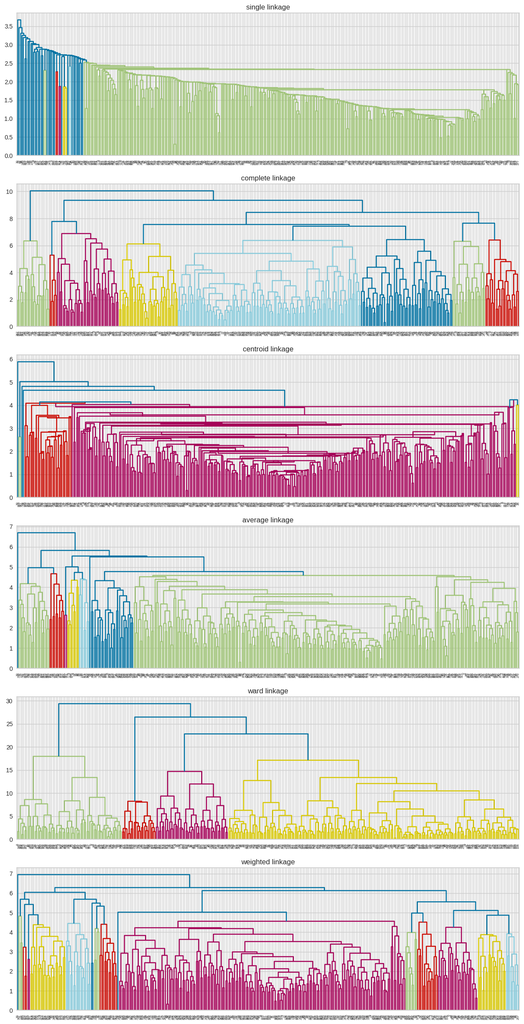

```python
linkage_methods = ["single", "complete", "centroid", "average", "ward", "weighted"]

fig, axs = plt.subplots(len(linkage_methods), 1, figsize=(15, 30))
for i, lm in enumerate(linkage_methods):
        Z = linkage(subset_scaled_df, metric= "euclidean", method=lm)

        dendrogram(Z, ax = axs[i])

        axs[i].set_title(lm + " linkage")
        c, coph_dists = cophenet(Z, pdist(subset_scaled_df))
```

Dendrograms for each linkage method. Based on these dendrograms it seems that the linkage methods that give the most distinct clusters are average and ward.

```python
HCModel = AgglomerativeClustering(n_clusters= 7, affinity = "euclidean", linkage = "average")
HCModel.fit(subset_scaled_df)
```

```
AgglomerativeClustering(affinity='euclidean', linkage='average', n_clusters=7)
```

```python
subset_scaled_df["HC_Clusters"] = HCModel.labels_
df["HC_Clusters"] = HCModel.labels_
```

```python
cluster_profile = subset_scaled_df.groupby("HC_Clusters").mean()
```

```python
print(cluster_profile)
```

```
             Current Price  Price Change  Volatility       ROE  Cash Ratio  \
HC_Clusters
0                -0.003671      0.071302   -0.248899 -0.032197   -0.135459
1                -0.617599     -0.802750    1.971054 -0.890906    0.910000
2                 1.337528      1.196919    0.248523 -0.369718    2.158792
3                 2.419145     -2.209917    2.174681  0.096953    2.699583
4                 2.419145     -0.072827    0.471889  2.116831   -1.081952
5                 0.631946      2.010733    2.224144  2.116831    2.506648
6                -0.901162     -1.540122    1.983219  0.825932   -0.420459

             Net Cash Flow  Net Income  Earnings Per Share  \
HC_Clusters
0                -0.040011    0.155454            0.171037
1                 1.226926   -0.628478           -1.131241
2                 0.603912   -0.083888            0.134491
3                -0.399121   -0.472475            2.114902
4                 0.015798   -0.961032           -1.911653
5                -0.004015   -0.901826           -1.137033
6                -0.444443   -1.633395           -1.820713

             Estimated Shares Outstanding  P/E Ratio  P/B Ratio
HC_Clusters
0                               -0.001088  -0.232982  -0.113841
1                                0.027208   1.121006   1.097114
2                                0.060218   1.224580   1.105181
3                               -1.145752   0.396384   2.312994
4                               -0.919633  -0.324468  -2.048462
5                               -0.752402   0.831483   1.166730
6                                0.129070   1.726247   0.136528
```

```python
#subset_scaled_df1 = subset_scaled_df.copy()
```

```python
#subset_scaled_df1["Company"] = df["Security"]
```

```python
for cl in df["HC_Clusters"].unique():
    print("companies in cluster {}:".format(cl))
    print(df[subset_scaled_df["HC_Clusters"] == cl]["Security"].unique())
    print()
```

```
companies in cluster 0:
['American Airlines Group' 'AbbVie' 'Abbott Laboratories'
 'Archer-Daniels-Midland Co' 'Alliance Data Systems' 'Ameren Corp'
 'American Electric Power' 'AFLAC Inc'
 'American International Group, Inc.' 'Apartment Investment & Mgmt'
 'Assurant Inc' 'Arthur J. Gallagher & Co.' 'Akamai Technologies Inc'
 'Albemarle Corp' 'Alaska Air Group Inc' 'Allstate Corp' 'Allegion'
 'Applied Materials Inc' 'AMETEK Inc' 'Affiliated Managers Group Inc'
 'Ameriprise Financial' 'American Tower Corp A' 'AutoNation Inc'
 'Anthem Inc.' 'Aon plc' 'Amphenol Corp' 'Arconic Inc'
 'Activision Blizzard' 'AvalonBay Communities, Inc.'
 'American Water Works Company Inc' 'American Express Co' 'Boeing Company'
 'Bank of America Corp' 'Baxter International Inc.' 'BB&T Corporation'
 'Bard (C.R.) Inc.' 'BIOGEN IDEC Inc.' 'The Bank of New York Mellon Corp.'
 'Ball Corp' 'Bristol-Myers Squibb' 'Boston Scientific' 'BorgWarner'
 'Boston Properties' 'Citigroup Inc.' 'Caterpillar Inc.' 'Chubb Limited'
 'CBRE Group' 'Crown Castle International Corp.' 'Carnival Corp.'
 'CF Industries Holdings Inc' 'Citizens Financial Group' 'Church & Dwight'
 'C. H. Robinson Worldwide' 'CIGNA Corp.' 'Cincinnati Financial'
 'Colgate-Palmolive' 'Comerica Inc.' 'CME Group Inc.' 'Cummins Inc.'
 'CMS Energy' 'Centene Corporation' 'CenterPoint Energy'
 'Capital One Financial' 'The Cooper Companies' 'CSX Corp.'
 'CenturyLink Inc' 'Cognizant Technology Solutions' 'Citrix Systems'
 'CVS Health' 'Chevron Corp.' 'Dominion Resources' 'Delta Air Lines'
 'Du Pont (E.I.)' 'Deere & Co.' 'Discover Financial Services'
 'Quest Diagnostics' 'Danaher Corp.' 'The Walt Disney Company'
 'Discovery Communications-A' 'Discovery Communications-C'
 'Delphi Automotive' 'Digital Realty Trust' 'Dun & Bradstreet'
 'Dover Corp.' 'Dr Pepper Snapple Group' 'Duke Energy' 'DaVita Inc.'
 'eBay Inc.' 'Ecolab Inc.' 'Consolidated Edison' 'Equifax Inc.'
 "Edison Int'l" 'Eastman Chemical' 'Equity Residential'
 'Eversource Energy' 'Essex Property Trust, Inc.' 'E*Trade'
 'Eaton Corporation' 'Entergy Corp.' 'Exelon Corp.' "Expeditors Int'l"
 'Expedia Inc.' 'Extra Space Storage' 'Ford Motor' 'Fastenal Co'
 'Fortune Brands Home & Security' 'FirstEnergy Corp'
 'Fidelity National Information Services' 'Fiserv Inc' 'FLIR Systems'
 'Fluor Corp.' 'Flowserve Corporation' 'FMC Corporation'
 'Federal Realty Investment Trust' 'General Dynamics'
 'General Growth Properties Inc.' 'Gilead Sciences' 'Corning Inc.'
 'General Motors' 'Genuine Parts' 'Garmin Ltd.' 'Goodyear Tire & Rubber'
```

[output cut: 66 more lines]

```

companies in cluster 1:
['Baker Hughes Inc' 'Concho Resources' 'EQT Corporation'
 'Frontier Communications' 'Halliburton Co.' 'Hess Corporation'
 'Hewlett Packard Enterprise' 'HP Inc.' 'Newmont Mining Corp. (Hldg. Co.)'
 'Netflix Inc.']

companies in cluster 4:
['Charter Communications']

companies in cluster 3:
['Chipotle Mexican Grill']

companies in cluster 5:
['Vertex Pharmaceuticals Inc' 'Wynn Resorts Ltd']
```

For average linkage, it seems that there are not distinct enough clusters, with three clusters having only one or two companies in them. A different linkage method should be used

```python
HCModel = AgglomerativeClustering(n_clusters= 4, affinity = "euclidean", linkage = "ward")
HCModel.fit(subset_scaled_df)
```

```
AgglomerativeClustering(affinity='euclidean', n_clusters=4)
```